# Exercise: initial values for the polio model

Aaron A. King and Edward L. Ionides

### Exercise

Discuss issues in specifying and inferring initial conditions, with particular reference to the polio example.

Suggest a possible improvement in the treatment of initial conditions here, code it up and make some preliminary assessment of its effectiveness. How will you decide if it is a substantial improvement?

### Solution

Changing the initial conditions involves trying a new specification of `rinit`.

After changing `rinit` (or any other model component) we can re-run the entire analysis and see whether anything is substantially different.

If the new specification involves additional parameters, we must also add transformations for them, if appropriate, and random walk specifications. We may also want to add them to the scatterplots. Nothing else in the code needs to be changed.

A simplifying approximation in the original `rinit` is to ignore initially infected babies, setting initial susceptibles to equal births and initial infected babies to zero.

Since the initial level of infection is low, and individuals do not stay long in the baby classes, this seems a reasonable approximation. Nevertheless, it is a testable one.

An alternative modeling approach is that babies might, to a first approximation, have the same prevalence as other individuals. `IO_0/SO_0` is the current infection proportion for susceptible adults. If we suppose babies are exposed to this infection rate each month of their infancy, we can replace the previous `rinit` accordingly. In practice, we use a more numerically stable alternative `IO_0/(IO_0+SO_0)` which is practically equivalent in the anticipated situation with low prevalence, but is guaranteed not to exceed unity in pathological situations that might arise during maximization. Specifically, we replace

```r
polio_rinit <- Csnippet("
  SB1 = SB1_0;
  SB2 = SB2_0;
  SB3 = SB3_0;
  SB4 = SB4_0;
  SB5 = SB5_0;
  SB6 = SB6_0;
  IB = 0;
  IO = IO_0 * P;
  SO = SO_0 * P;
")
```

by

```r
polio_rinit <- Csnippet("
  double p=IO_0/(IO_0+SO_0);
  SB1 = SB1_0 * pow(1-p,1);
  SB2 = SB2_0 * pow(1-p,2);
  SB3 = SB3_0 * pow(1-p,3);
  SB4 = SB4_0 * pow(1-p,4);
  SB5 = SB5_0 * pow(1-p,5);
  SB6 = SB6_0 * pow(1-p,6);
  IB = (SB1+SB2+SB3+SB4+SB5+SB6) * p/(1-p);
  IO = IO_0 * P;
  SO = SO_0 * P;
")
```

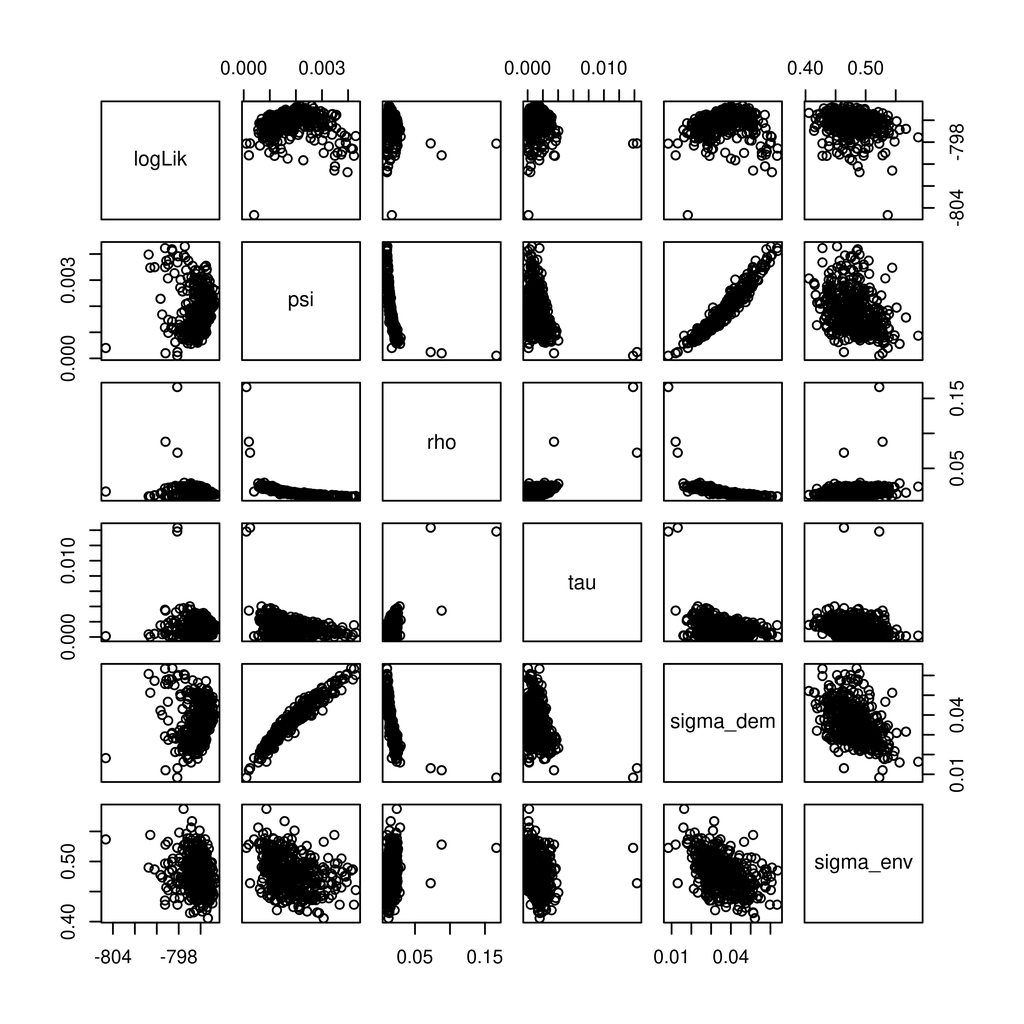

This version produced in R 4.3.2 on February 19, 2024.

Top of this document  
Previous page  
Back to the lesson  
Course homepage  
Acknowledgments

Licensed under the [Creative Commons Attribution-NonCommercial license](http://creativecommons.org/licenses/by-nc/4.0/). Please share and remix noncommercially, mentioning its origin.